# Chapter 03 Data Visualization

## Aesthetic mappings

### Content

use another aesthetic to add a third variable, class, and use color at unique levels to differenciate each unique value of the class-variable

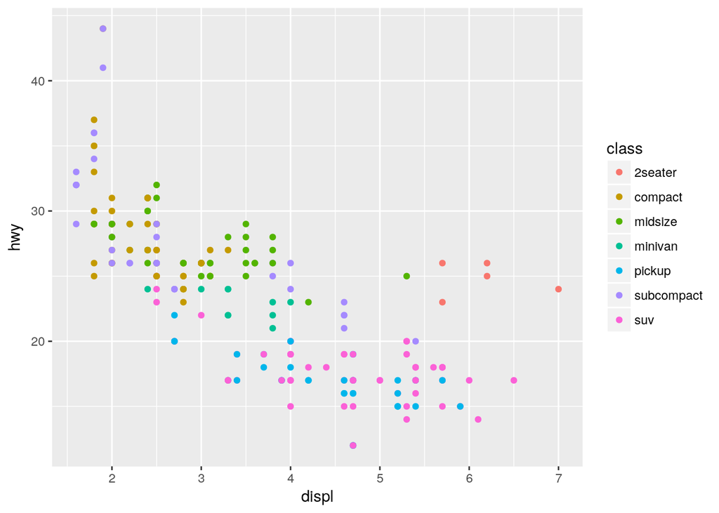

```r
ggplot(data = mpg) +
  geom_point(mapping = aes(x = displ, y = hwy, color = class))
```

other possible aethetics:

- size (=> size of the points)
- alpha (=> opacity)
- shape (=> shapes, only six possible ones; rest will stay unplotted)

manually setting the aesthetic: since setting an aesthetic to a constant is independent of any variable, set this **outside** of the aes()-function

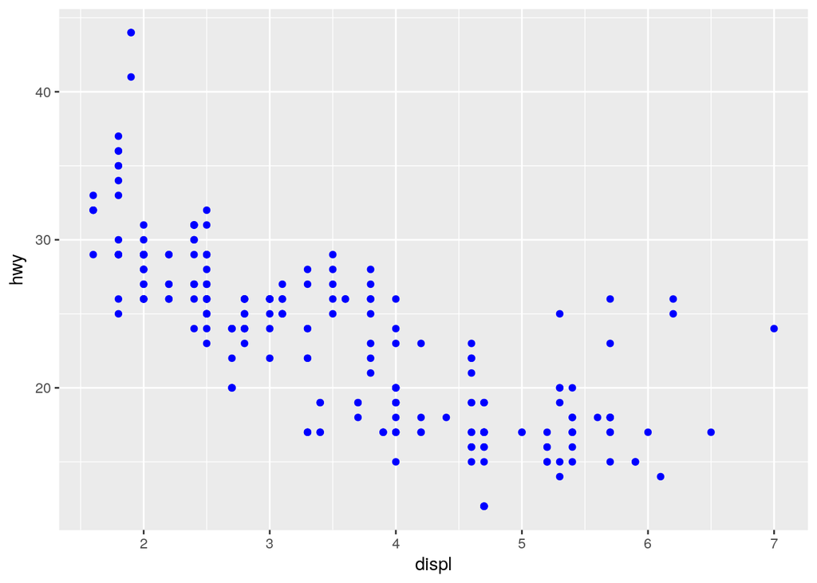

```r
ggplot(data = mpg) +
  geom_point(mapping = aes(x = displ, y = hwy), color = "blue")
```

### Exercises

1. What’s gone wrong with this code? Why are the points not blue?

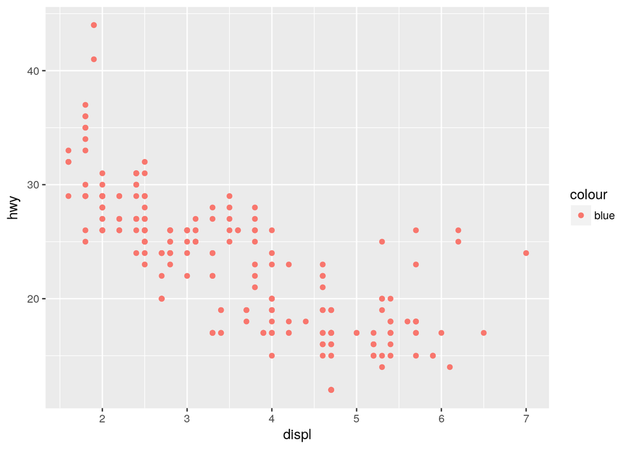

   ```r
   ggplot(data = mpg) +
     geom_point(mapping = aes(x = displ, y = hwy, color = "blue"))
   ```

   It’s not blue because the color setting was used inside aes() The correct way:

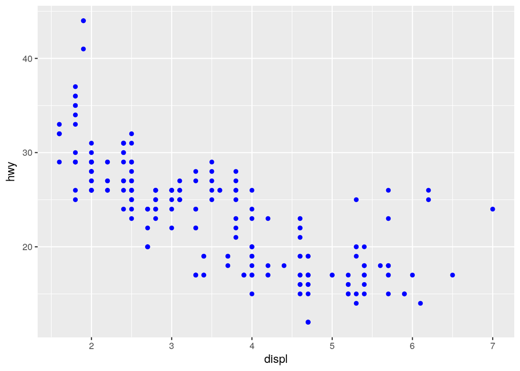

   ```r
   ggplot(data = mpg) +
     geom_point(mapping = aes(x = displ, y = hwy), color = "blue")
   ```

2. Which variables in `mpg` are categorical? Which variables are continuous? (Hint: type `?mpg` to read the documentation for the dataset). How can you see this information when you run `mpg`?

   ```r
   lapply(mpg, class)
   ```

   ```
   ## $manufacturer
   ## [1] "character"
   ##
   ## $model
   ## [1] "character"
   ##
   ## $displ
   ## [1] "numeric"
   ##
   ## $year
   ## [1] "integer"
   ##
   ## $cyl
   ## [1] "integer"
   ##
   ## $trans
   ## [1] "character"
   ##
   ## $drv
   ## [1] "character"
   ##
   ## $cty
   ## [1] "integer"
   ##
   ## $hwy
   ## [1] "integer"
   ##
   ## $fl
   ## [1] "character"
   ##
   ## $class
   ## [1] "character"
   ```

   continuous variables:

   ```r
   colnames(mpg)[grep("numeric", lapply(mpg, class))]
   ```

   ```
   ## [1] "displ"
   ```

   categorial variables:

   ```r
   colnames(mpg)[grep("character", lapply(mpg, class))]
   ```

   ```
   ## [1] "manufacturer" "model"        "trans"        "drv"
   ## [5] "fl"           "class"
   ```

   discrete variables:

   ```r
   colnames(mpg)[grep("integer", lapply(mpg, class))]
   ```

   ```
   ## [1] "year" "cyl"  "cty"  "hwy"
   ```

3. Map a continuous variable to `color`, `size`, and `shape`. How do these aesthetics behave differently for categorical vs. continuous variables?

   `color`:

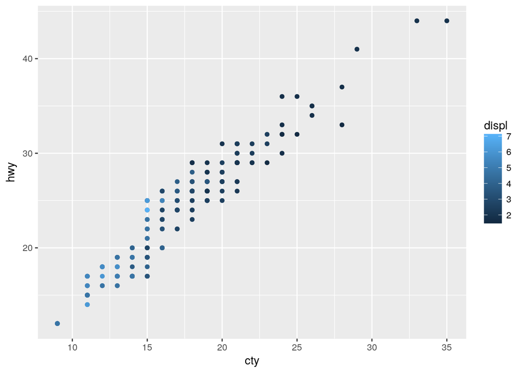

   ```r
   ggplot(data = mpg) +
     geom_point(mapping = aes(x = cty, y = hwy, color = displ))
   ```

   `size`:

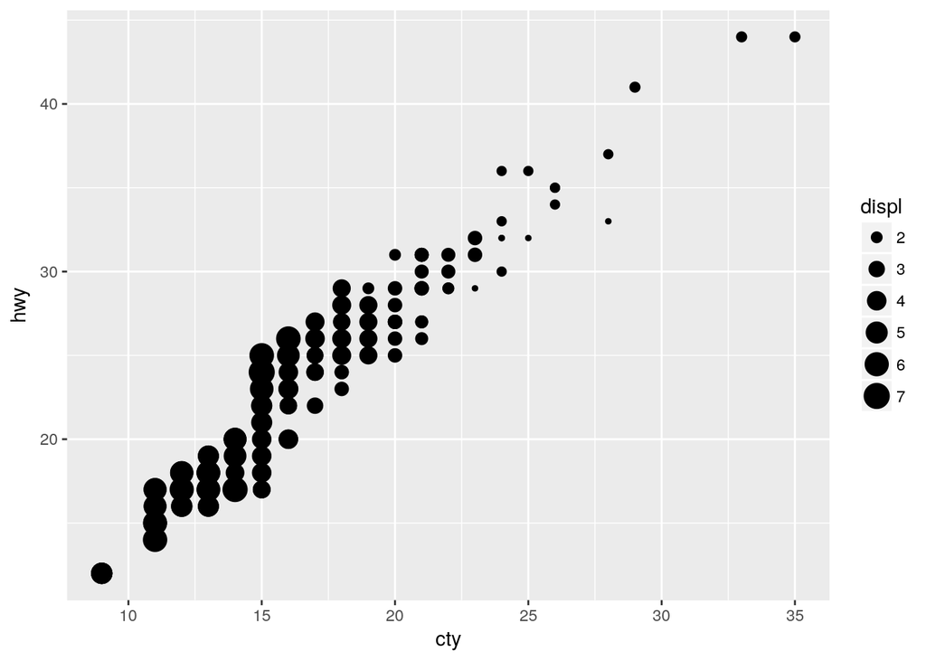

   ```r
   ggplot(data = mpg) +
     geom_point(mapping = aes(x = cty, y = hwy, size = displ))
   ```

   `size` & `color` work well, `shape` is more suited for categorial variables

   `color`:

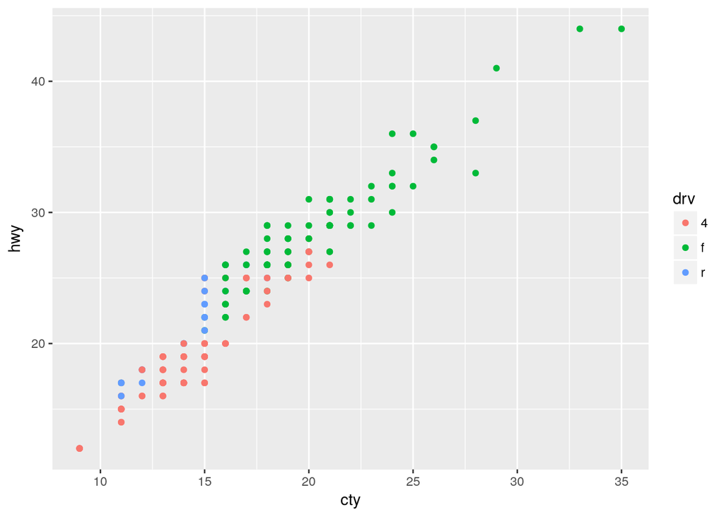

   ```r
   ggplot(data = mpg) +
     geom_point(mapping = aes(x = cty, y = hwy, color = drv))
   ```

   `size`:

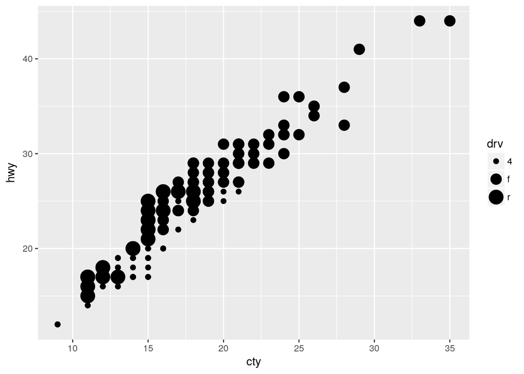

   ```r
   ggplot(data = mpg) +
     geom_point(mapping = aes(x = cty, y = hwy, size = drv))
   ```

   `shape`:

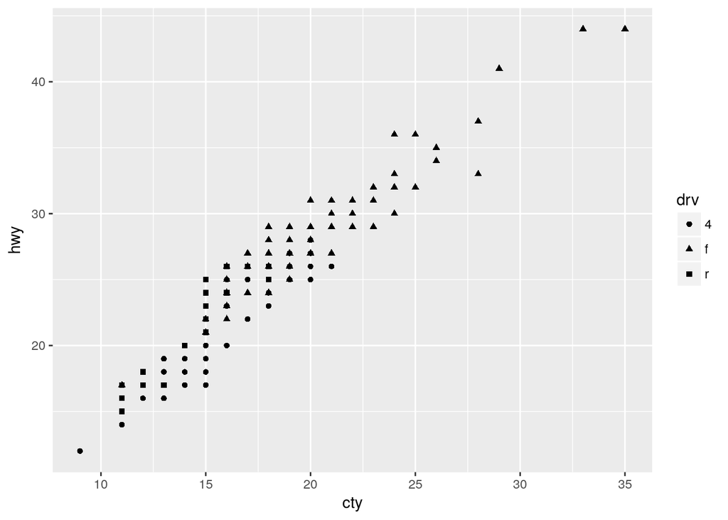

   ```r
   ggplot(data = mpg) +
     geom_point(mapping = aes(x = cty, y = hwy, shape = drv))
   ```

   `color` and `shape` work well, `size` is better for discrete/continuous variables
4. What happens if you map the same variable to multiple aesthetics?

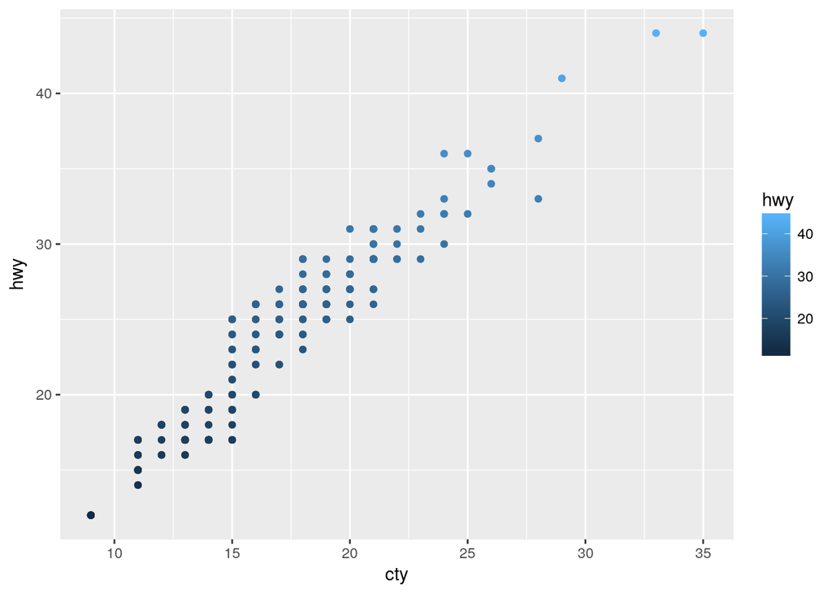

   ```r
   ggplot(data = mpg) +
     geom_point(mapping = aes(x = cty, y = hwy, color = hwy))
   ```

   ```r
   ?geom_point
   ```

   > For shapes that have a border (like 21), you can colour the inside and outside separately. Use the stroke aesthetic to modify the width of the border

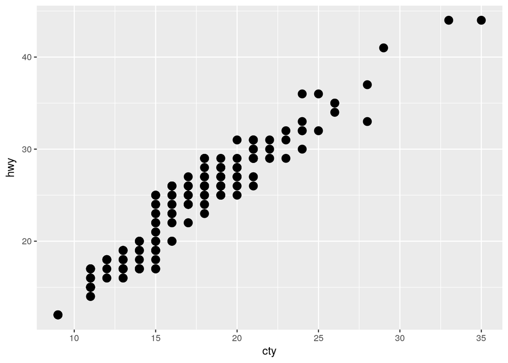

   ```r
   ggplot(data = mpg) +
     geom_point(mapping = aes(x = cty, y = hwy, stroke = 2))
   ```

6. What happens if you map an aesthetic to something other than a variable name, like `aes(colour = displ < 5)`?

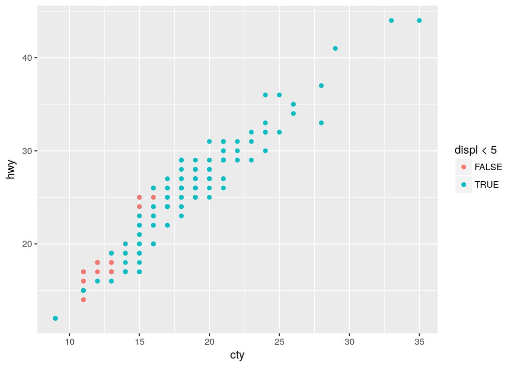

   ```r
   ggplot(data = mpg) +
     geom_point(mapping = aes(x = cty, y = hwy, color = displ < 5))
   ```

   This creates a logical vector indicating whether the condition is true or not and displays these two levels as the third aesthetic in the legend

## Common problems

## Facets

### Content

### Exercises

1. What happens if you facet on a continuous variable?

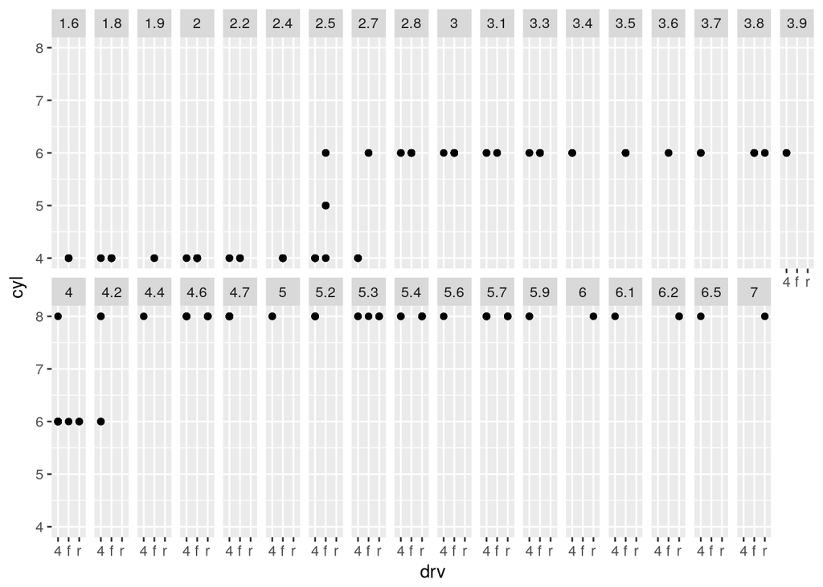

   ```r
   ggplot(data = mpg) +
     geom_point(aes(x = drv, y = cyl)) +
     facet_wrap(~ displ, nrow = 2)
   ```

   For every realisation of the variable a new facet will be added.
2. What do the empty cells in plot with `facet_grid(drv ~ cyl)` mean? How do they relate to this plot?

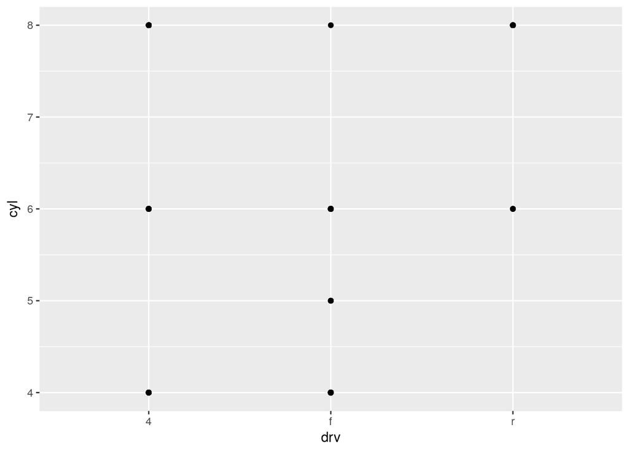

   ```r
   ggplot(data = mpg) +
     geom_point(mapping = aes(x = drv, y = cyl))
   ```

   There are points missing whenever there is no realisation in the data as `cyl` for that `drv`.
3. What plots does the following code make? What does `.` do?

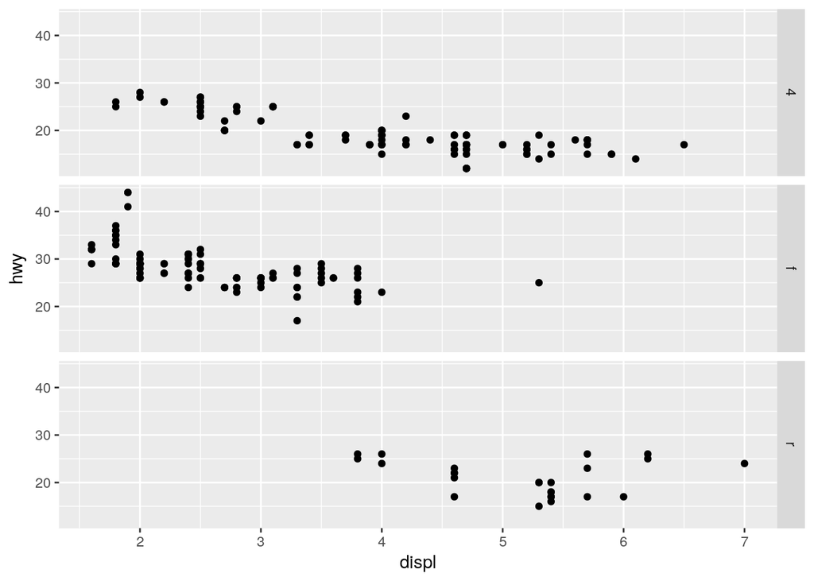

   ```r
   ggplot(data = mpg) +
     geom_point(mapping = aes(x = displ, y = hwy)) +
     facet_grid(drv ~ .)
   ```

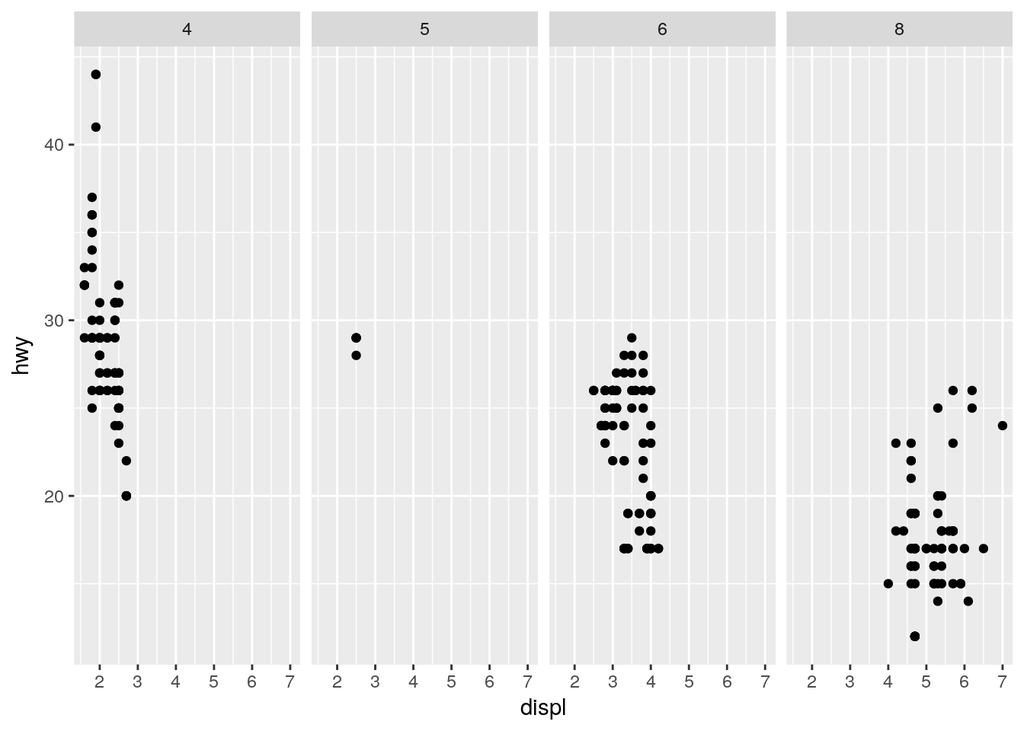

   ```r
   ggplot(data = mpg) +
     geom_point(mapping = aes(x = displ, y = hwy)) +
     facet_grid(. ~ cyl)
   ```

   The `facet_grid` formula works according to the pattern `y ~ x`, where the y variable is mapped along the y-axis of the plot (as rows) and the x variable is mapped along the x-axis (as columns).

   When instead of a variable, there is a dot, that means to omit that dimension. (`. ~ x` to map `x` along columns and `y ~ .` to map `y` along rows).
4. Take the first faceted plot in this section:

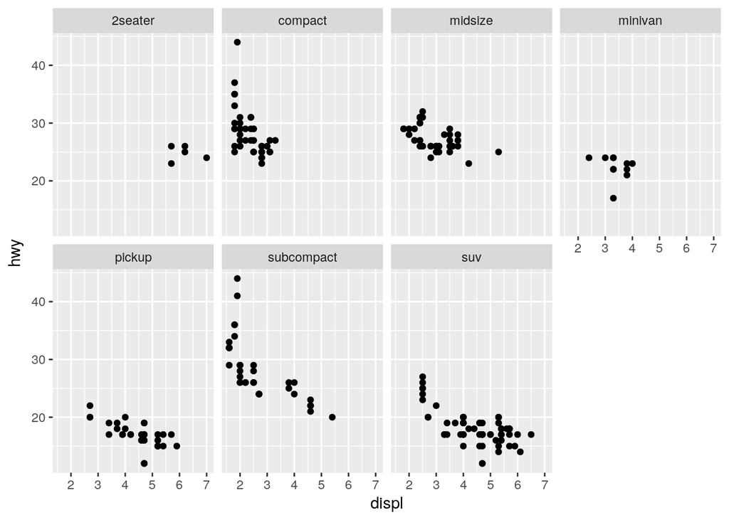

   ```r
   ggplot(data = mpg) +
     geom_point(mapping = aes(x = displ, y = hwy)) +
     facet_wrap(~ class, nrow = 2)
   ```

   What are the advantages to using faceting instead of the colour aesthetic? What are the disadvantages? How might the balance change if you had a larger dataset?
   - advantages: Faceting gives a plot per level. That means that it’s easier to spot how the data for each level is distributed within the x- and y-axes. This is especially helpful for larger datasets, where the data points from different facets might overlap.
   - disadvantages: Since levels are split up over multiple plots, it is harder to spot outliers or clusters in the data.
5. Read `?facet_wrap`. What does `nrow` do? What does `ncol` do? What other options control the layout of the individual panels? Why doesn’t `facet_grid()` have `nrow` and `ncol` variables?

   `facet_wrap()` builds facetting for one vector. `nrow` and `ncol` set the number of rows and columns along which the facets of that vector should be distributed in the plot.

   `facet_grid()` has predetermined numbers of rows and columns. The number of rows is equal to the number of levels for the `y` variable and the number of columns to the number of level for the `x` variable specified in the formula `y ~ x`.
6. When using `facet_grid()` you should usually put the variable with more unique levels in the columns. Why?

   This makes sense because most displaying devices have a larger number of pixels on the horizontal than the vertical axis.

## Geometric objects

### Content

### Exercises

1. What geom would you use to draw a line chart? A boxplot? A histogram? An area chart?
   - line: `geom_line()`
   - boxplot: `geom_boxplot()`
   - histogram: `geom_histogram()`
   - area chart: `geom_area()`
2. Run this code in your head and predict what the output will look like. Then, run the code in R and check your predictions.

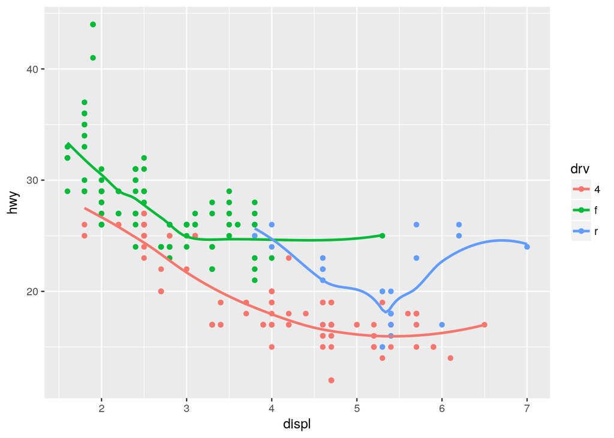

   ```r
   ggplot(data = mpg, mapping = aes(x = displ, y = hwy, color = drv)) +
     geom_point() +
     geom_smooth(se = FALSE)
   ```

   This plot will show a scatter plot of `hwy` against `displ` with an additional aesthetic for `drv` by color. On top, there will be a smoothed regression line per level of `drv` without a confidence interval being displayed.
3. What does `show.legend = FALSE` do? What happens if you remove it?  
   Why do you think I used it earlier in the chapter?

   It didn’t occur earlier in the chapter… But it stops the legend from being displayed.
4. What does the `se` argument to `geom_smooth()` do?

   `se` shows whether a confidence interval should be displayed around the smoothed curve.
5. Will these two graphs look different? Why/why not?

   ```r
   ggplot(data = mpg, mapping = aes(x = displ, y = hwy)) +
     geom_point() +
     geom_smooth()

   ggplot() +
     geom_point(data = mpg, mapping = aes(x = displ, y = hwy)) +
     geom_smooth(data = mpg, mapping = aes(x = displ, y = hwy))
   ```

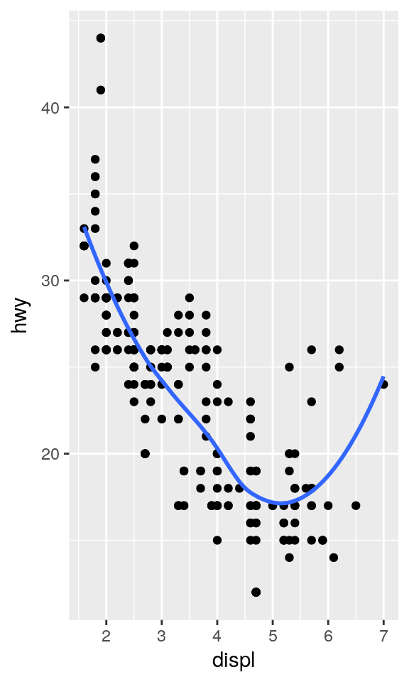

[figure not shown]

[figure not shown]

[figure not shown]

[figure not shown]

[figure not shown]

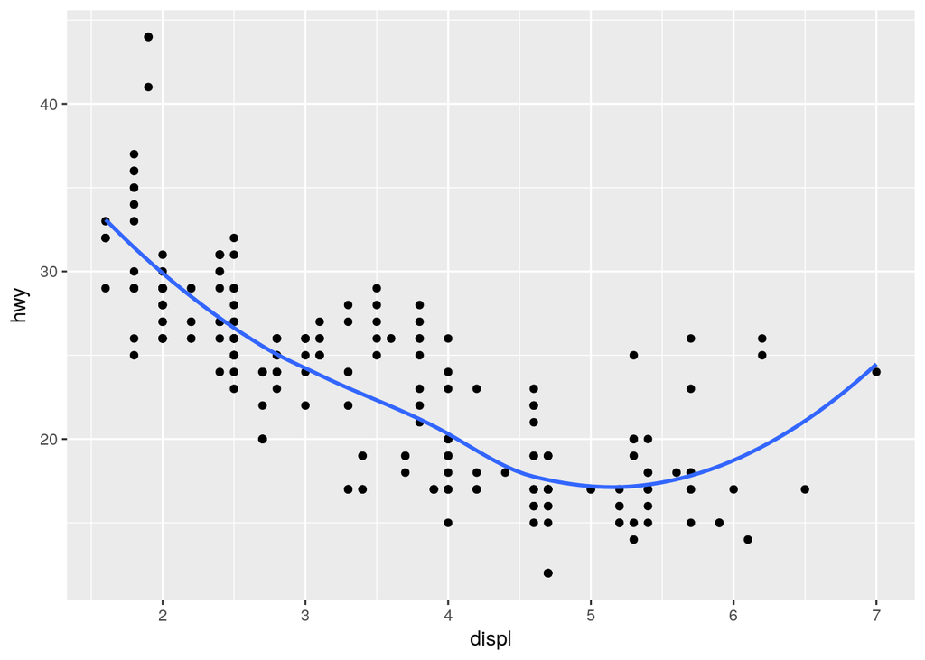

   ```r
   ggplot(mpg, aes(x = displ, y = hwy)) +
     geom_point() +
     geom_smooth(se = F)
   ```

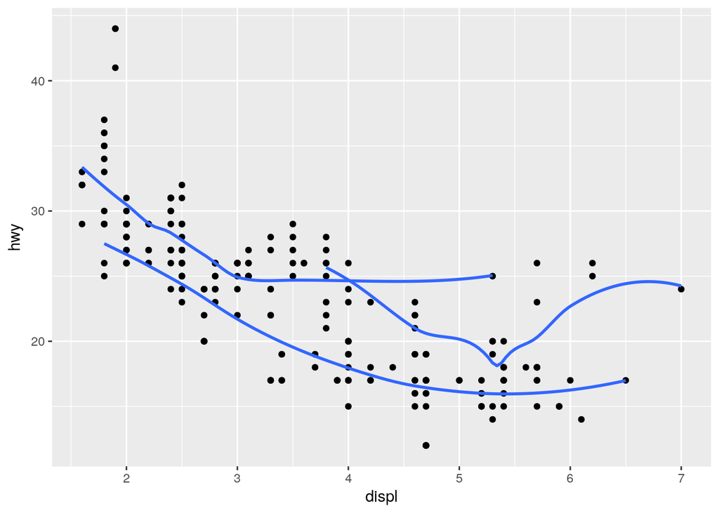

   ```r
   ggplot(mpg, aes(x = displ, y = hwy, group = drv)) +
     geom_point() +
     geom_smooth(se = F)
   ```